# 2021_Lab10_Photoreceptors_4.9_Pietro_Bonazzi

##### Neuromorphic engineering I

## Photoreceptors; Photoreceptor Circuits

Created Oct 2020-Dec 2020 by Tobi Delbruck & Rui Graca

#### Group number: 4.9

#### Team members

- Pietro Bonazzi
- Wencan Huang

#### TA:

**Objectives of this lab**

### Exercise type and dates

COVID made it too difficult to set up a remote arrangement for testing the classchip photoreceptor circuits. Instead, we will do some circuit analysis and numerical evaluation to understand the concepts of feedback, loop gain, and transimpedence speedup.

The exercise spans 2 weeks with 2h per week. There will be two groups Thursday afternoon and Monday morning.

Excercise dates: Monday group: Nov 30, Dec 7, Thursday group: Dec 2, Dec 9, Monday group: Dec 6 and Dec 13.

Due date: Dec 20 2021

### Running the notebook

You will run this exercise on your own computer using any available Jupyter server. If you have one already, you can use it. But you don't need to: https://www.dataschool.io/cloud-services-for-jupyter-notebook/ provides a list of free servers on the cloud that you can use after registration.

### Requirements: libraries needed

python 3.7+

You might need to install libraries. You can install them from terminal into your python enviroment with

```
pip install jupyter matplotlib numpy  scipy engineering_notation engineering_notation
```

Remember, when using any python, conda is your friend. Make a unique conda enviroment for each project to save yourself a lot of trouble with conflicting libraries. Here we will use only very standard libraries that are provided by all the Jupyter servers.

```python
import matplotlib.pyplot as plt # plotting
import numpy as np # for math
from scipy.integrate import solve_ivp #  - for timestepping ODEs
import os
from engineering_notation import EngNumber as eng # useful library to e.g. format eng(1e-3) as 1m
from scipy.stats import linregress

### ------------------------------------------------------------------------------------------------------------------------------------------------------------
```

```python
import matplotlib as mpl
mpl.rcParams["figure.facecolor"] = "white"
mpl.rcParams["axes.facecolor"] = "white"
mpl.rcParams["savefig.facecolor"] = "white"
```

### Define useful constants

```python
I_0= 1e-14 # FET off current - you measured it TODO check correct for classchip process
U_T= 25e-3# you better know this
kappa=.8 # choose a reasonable value
vdd=1.8 # power supply voltage
q=1.6e-19 # charge of electron

V_e=10 # Early voltage for the TI photoreceptor amplifier input FET that we will use later. 1V is very small and would be less than what you would get from minimum length FET
```

### Define useful functions

Let's define a function for subthreshold current that includes optional Early voltage for finite drain conductance:

```python
def id_sub(V_g, V_s=0, V_d=1.8, U_T=U_T, I_0=I_0, kappa=kappa, V_e=V_e):
    """ Computes the drain current from gate, source and drain voltage.
    At most one of V_g, V_s, V_d can be a vector in which case I_d is a vector

    :param V_g: gate voltage
    :param V_s: source voltage, by default 0
    :param V_d: drain voltage, by default 1V
    :param: U_T: thermal voltage
    :param I_0: the off current
    :param V_e: the Early voltage; drain conductance is Idsat/V_e

    :returns: the drain current in amps
    """
    Vds=V_d-V_s
    Id_sat=I_0*np.exp(((kappa*V_g)-V_s)/U_T)
    I_d=Id_sat*(1-np.exp(-Vds/U_T))
    if V_e!=np.infty:
        I_d=I_d*(1+Vds/V_e)
    return I_d
```

Check that the subthreshold equation makes sense. Start by plotting the drain current versus gate voltage, and check that the slope is 1 e-fold per U_T/kappa.

```
Transconductance: Measured efold current gate voltage=31.25mV, predicted from U_T/kappa=31.25mV
Transconductance OK
```

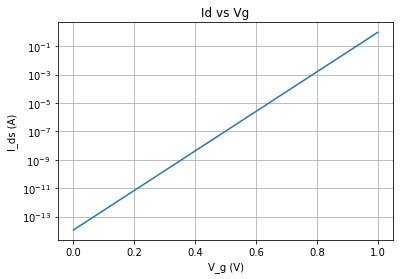

```python
import matplotlib.pyplot as plt # plotting
import numpy as np # for math
vg=np.linspace(0,1,100)
# drain current vs gate voltage (transconductance)
idvsvg=id_sub(vg)

plt.figure('idsat')
plt.semilogy(vg,idvsvg)
plt.xlabel('V_g (V)')
plt.ylabel('I_ds (A)')
plt.title('Id vs Vg')
plt.grid(True)

reg=linregress(np.log(idvsvg), vg )
efold_v_meas=reg[0]
efold_v_theory=U_T/kappa
print(f'Transconductance: Measured efold current gate voltage={eng(efold_v_meas)}V, predicted from U_T/kappa={eng(efold_v_theory)}V')
if np.abs((efold_v_meas-efold_v_theory)/(.5*(efold_v_meas+efold_v_theory)))>.01:
    raise ValueError('Something wrong with subthreshold equations')
else:
    print('Transconductance OK')
```

Now plot the drain current vs drain voltage and check that the actual drain conductance matches the expected value.

```
Output conductance: Measured g_out=9.04n, predicted from g_out=Id_sat/Ve=8.89n
Drain conductance OK within 5%
```

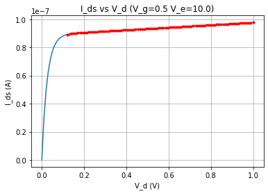

```python
vd=np.linspace(0,1,100)
V_g=.5
idsat=I_0*np.exp(kappa*V_g/U_T)
# drain current vs drain voltage (drain conductance)
idvsvd=id_sub(V_g=V_g, V_d=vd, V_e=V_e)

plt.figure('idsat2')
plt.plot(vd,idvsvd)
plt.xlabel('V_d (V)')
plt.ylabel('I_ds (A)')
plt.grid(True)
plt.title('I_ds vs V_d (V_g={:.1f} V_e={:.1f})'.format(V_g,V_e))

r=[i for i in range(len(idvsvd)) if idvsvd[i] >= idsat]

plt.plot(vd[r],idvsvd[r],'.r')
reg=linregress(vd[r], idvsvd[r] )
gout_meas= reg[0]
gout_pred=I_0*np.exp(kappa*V_g/U_T)/V_e
print(f'Output conductance: Measured g_out={eng(gout_meas)}, predicted from g_out=Id_sat/Ve={eng(gout_pred)}')
if np.abs((gout_meas-gout_pred)/(.5*(gout_meas+gout_pred)))>.05:
    raise ValueError('Something wrong with subthreshold equations')
else:
    print('Drain conductance OK within 5%')
```

It seems to make sense. Now we have an equation we can use in ODE equation for photoreceptors

### Estimating actual photocurrent

We will also assume a photodiode area of 10um^2 which is a reasonably-large photodiode, and we will assume a not-so-great junction leakage "dark current" of 1nA/cm^2.

```python
scene_flux_lux=10 # 1 lux is about ten times moonlight
photodiode_area_um2=10 # photodiode area m^2
# optics reduces light intensity by square of aperture ratio
# we will assume a cheap f/3 lens with ratio focal length to aperture of 3
def optics_reduction(flux): f_number=3; return flux/(4*f_number*f_number)
avg_reflectance=.18 # kodak's estimate of average scene reflectance
chip_flux_lux=optics_reduction(scene_flux_lux)
photons_per_um2_per_lux=1e4 # you get about this many photons per lux falling on chip with "visible" sunlight spectrum
photocurrent_e_per_sec=chip_flux_lux*(photons_per_um2_per_lux)*photodiode_area_um2
dark_current_amps_per_um2=(1e-9/1e-4)*1e-12 # junction leakage per m^2
dark_current_amps=photodiode_area_um2*dark_current_amps_per_um2
dark_current_e_per_sec=dark_current_amps/q
photocurrent_amps=photocurrent_e_per_sec*q
photocurrent_total_amps=photocurrent_amps+dark_current_amps

print(f'scene illumination level {eng(scene_flux_lux)}lux\n'
      f'photodiode area: {photodiode_area_um2}um^2\n'
      f'DC photocurrent: {eng(photocurrent_total_amps)}A\n'
      f'dark current: {eng(dark_current_e_per_sec)}e/s or {eng(dark_current_amps)}A\n'
      f'I_0 off current: {eng(I_0/q)}e/s or {eng(I_0)}A\n')
```

```
scene illumination level 10lux
photodiode area: 10um^2
DC photocurrent: 4.54fA
dark current: 625e/s or 100aA
I_0 off current: 62.50ke/s or 10fA
```

Is the value smaller than the off-current? This is not surprising; under dark conditions, the photocurrent can be a small fraction of the FET off-current.

#### Making a photocurrent stimulus waveform

Now we will make a waveform input stimulus to drive our time-domain simulations of the photoreceptors. Let's define our input photocurrent waveform we will use it is a square wave with modulation of contrast signal_contrast and starts with bright DC level and then goes to dark DC level

```
source follower photodiode capacitance C_pd=100fF and tau_sf=5.63s
Computed period: 11.25s
```

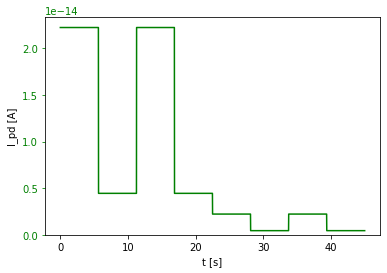

```python
import numpy as np
from scipy.signal import square
import matplotlib.pyplot as plt # plotting

dark=dark_current_amps # dark current level
sigdc1=photocurrent_amps # DC photocurrent for bright half
sigdc2=photocurrent_amps/10 # and dark half
signal_contrast=5 # contrast in each half, i.e. cont=10 means that the bright part will be 10 times the dark half period, 2 means 2 times
nper=2 # how many periods to simulate for each half bright/dark
# to compute the period, let's make it so that half a period is 1 time constants for SF in dark part of scene
C_pd=100e-15 # guesstimate about 100fF
tau_sf=C_pd*U_T/sigdc2
per=2*tau_sf # period in seconds

print(f'source follower photodiode capacitance C_pd={eng(C_pd)}F and tau_sf={eng(tau_sf)}s\n'
      f'Computed period: {eng(per)}s')
dt=per/500 # timesteps per half period
time_basis=np.arange(0,2*nper*per,dt) # start,stop,step generate time basis that is nper long
npts=len(time_basis)
npts2=int(npts/2)
# generate square wave with period per using time basis t that has steps dt
# square(x) has period 2*pi, i.e. its output is 1 when input is 0-pi, then -1 for pi-2pi, then 1 again
# thus if we want to have nper cycles in each half of our stimulus, we need to
# make its argument go to 2pi when the time goes to per
# Also, shift it up and divide by 2 to get 0-1 modulated square
sq=(square((2*np.pi*time_basis)/(per))+1)/2
# convolve with a short box filter to
# make the edges not perfectly square to simulate finite optical aperture
# sq=np.convolve(sq,np.ones(10)/10,mode='same') # causes some wierd transient, didn't debug

sig=np.zeros_like(sq)
sig[:npts2]=sigdc1*(1+(signal_contrast-1)*sq[:npts2])
sig[npts2+1:]=sigdc2*(1+(signal_contrast-1)*sq[npts2+1:])
sig[npts2]=sigdc2*(1+(signal_contrast-1)*sq[npts2+1])
photocurrent_waveform=sig
# plt.plot(t,cur)

fig,ax1=plt.subplots(sharex=True)
ax1.plot(time_basis,photocurrent_waveform,'g',)
ax1.set_ylim([0,None])
ax1.set_yscale('linear')
ax1.set_xscale('linear')
ax1.tick_params(axis='y', colors='green')
ax1.set_xlabel('t [s]')
ax1.set_ylabel('I_pd [A]')
```

We need to make a function out of our nice I_pd vector so that we can get I_pd at any point in time

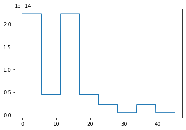

```python
def find_nearest_idx(array,value):
    idx = np.searchsorted(array, value, side="right")
    return idx
def I_pd_function(time,time_basis,photocurrent_waveform):
    idx=find_nearest_idx(time_basis,time)
    idx-=1 # go to next point just to left since search finds point just before time
    if idx<0: return photocurrent_waveform[0]
    if idx>=(len(time_basis)-1): return photocurrent_waveform[-1]
    t1=time_basis[idx]
    i1=photocurrent_waveform[idx]
    idx+=1
    t2=time_basis[idx]
    i2=photocurrent_waveform[idx]
    tfrac=(time-t1)/(t2-t1) if t2-t1>0 else .5
    i=(1-tfrac)*i1+tfrac*i2
    return i
I_pd = lambda t: I_pd_function(t,time_basis,photocurrent_waveform)
# test it
ttest=np.linspace(0,time_basis[-1],1000)
itest=[]
for t in ttest: itest.append(I_pd(t))
itest=np.array(itest)
plt.plot(ttest,itest)
```